# Assignment 2

Differential Gene expression and Preliminary ORA

Keren Zhang

2025-04-01

## Introduction

In the study by Liu et al. (2024), they particularly focused on lung adenocarcinoma (LUAD), one of the most common and deadly forms of cancer worldwide(Zappa & Mousa, 2016). It is known to spread to distant parts of the body in about half of the patients even after surgical removal of the tumor(Liu et al., 2024). To better understand and find ways to treat this spreading, or metastasis, they have developed a new experimental model using patient-derived organoids (PDOs). PDOs are three-dimensional cell cultures taken from patients’ tumors that mimic the real biological environment of lung cancer. In addition to PDOs, the study also utilized metastasis-derived organoids (MDOs), which were harvested from different metastatic sites, including the brain, diaphragm, liver, and gallbladder, to model and investigate the mechanisms driving LUAD metastasis and potential therapeutic vulnerabilities.

### Previous Work

The dataset employed for Assignment 1 was sourced from the [LUAD study](https://pubmed.ncbi.nlm.nih.gov/39413736/) study, available under the GEO accession number GSE276387.

Steps taken previously to prepare the dataset for analysis:

- **Data Mapping**:
  - Mapped genes to HUGO Gene Nomenclature Committee (HGNC) symbols
- **Data Cleaning**:
  - Removal of missing values and duplicate genes to ensure data integrity.
- **Outlier Removal**:
  - Outliers were identified and removed to enhance the robustness of the analysis.
- **Data Normalization**:
  - Employed the Trimmed Mean of M-values (TMM) method for normalization to minimize technical variance.

Following the processing done on the original 57445 genes from A1, we are left with 17195 genes over 14 samples (5 Patient Derived Organoid samples, 5 Metastasis Derived Organoid samples, and 4 Human Tumor Samples).

### Next Tasks

#### Load Normalized Data

```r
normalized_luad_data <- read.csv("normalized_luad_log2.csv")
```

```r
data_set_geoid <- "GSE276387"
```

## Differential Gene Expression

The normalized dataset includes 5 Patient Derived Organoid (PDO) samples, 5 Metastasis Derived Organoid (MDO) samples, and 4 Human Tumor samples. These sample types will serve as the primary factors in the DGE analysis due to their direct relevance and distinct biological origins.

### Limma MDS

As `Limma` has been updated to include improved tools for RNASeq data, it will be used to generate the Multi-Dimensional Scaling (MDS) plot for the normalized data.

```r
luad_matrix <- normalized_luad_data[, -1]

rownames(luad_matrix) <- normalized_luad_data$X  # Since 'X' contains gene names or IDs
colnames(luad_matrix) <- colnames(normalized_luad_data[, 2:ncol(normalized_luad_data)])


limma::plotMDS(luad_matrix, labels=NULL, pch=1,
               col = c("blue",
                       "purple", "green")[factor(sample_type_df$`Cell Type`)])
```

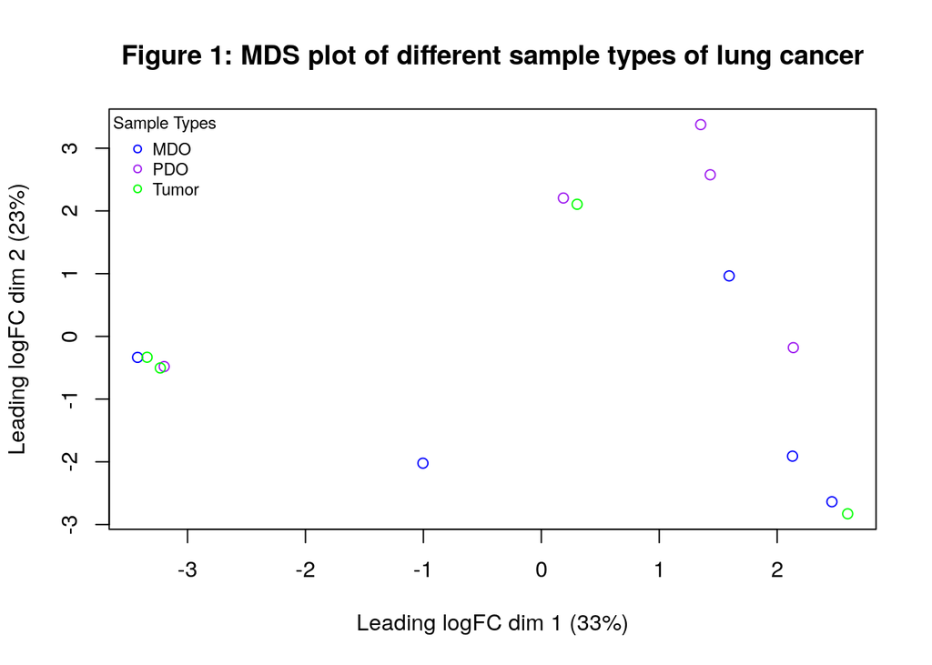

```r
title("Figure 1: MDS plot of different sample types of lung cancer")
legend("topleft",
       legend=levels(factor(sample_type_df$`Cell Type`)),
       pch=c(1), col=c("blue", "purple", "green"),
       title = "Sample Types", bty='n', cex=0.75)
```

In the MDS plot above, blue points represent the MDO samples, purple represents the PDO samples and green represents the tumour samples. Some clustering could be observed, although it is not distinctly defined.

### Model Setup

```r
# Ensure that the factor is correctly ordered if necessary
sample_type_df$`Cell Type` <- factor(sample_type_df$`Cell Type`, levels = c("Tumor", "MDO", "PDO"))

# Create the model design matrix
model_design <- model.matrix(~ sample_type_df$`Cell Type`)

# Display the first few rows of the design matrix
model_design[1:5,]
```

```
##   (Intercept) sample_type_df$`Cell Type`MDO sample_type_df$`Cell Type`PDO
## 1           1                             0                             0
## 2           1                             1                             0
## 3           1                             1                             0
## 4           1                             1                             0
## 5           1                             1                             0
```

### DGE - EdgeR

#### 1.1 Calculate p-values for each of the genes in your expression set.

```r
d = DGEList(counts=luad_matrix, group=sample_type_df$`Cell Type`)

# Estimate Dispersion
d <- estimateDisp(d, model_design)


#fit the model

fit <- glmQLFit(d, model_design)

qlf.Tumor_vs_MDO <- glmQLFTest(fit, coef='sample_type_df$`Cell Type`MDO')

qlf.Tumor_vs_PDO <- glmQLFTest(fit, coef='sample_type_df$`Cell Type`PDO')

# kable(topTags(qlf.Tumor_vs_MDO), type="html",row.names = TRUE)
```

#### 1.2 How many genes were significantly differentially expressed?

```r
# For MDO vs. Tumor Comparison
qlf_MDO_hits <- topTags(qlf.Tumor_vs_MDO, sort.by = "PValue",
                  n = nrow(luad_matrix))

DGE_MDO <- length(which(qlf_MDO_hits$table$PValue < 0.05))

print(paste("# of significantly differentially expressed genes MDO vs. Tumor:", DGE_MDO))
```

```
## [1] "# of significantly differentially expressed genes MDO vs. Tumor: 332"
```

```r
# For PDO vs. Tumor Comparison
qlf_PDO_hits <- topTags(qlf.Tumor_vs_PDO, sort.by = "PValue",
                  n = nrow(luad_matrix))

DGE_PDO <- length(which(qlf_PDO_hits$table$PValue < 0.05))

print(paste("# of significantly differentially expressed genes PDO vs. Tumor:", DGE_PDO))
```

```
## [1] "# of significantly differentially expressed genes PDO vs. Tumor: 631"
```

- For the comparison between Tumor and MDO (Metastasis-Derived Organoids), there are **332** genes that are significantly differentially expressed.
- For the comparison between Tumor and PDO (Patient-Derived Organoids), there are **631** genes that are significantly differentially expressed.

#### 1.3 What thresholds did you use and why

In the differential expression analysis performed using `edgeR`, a quasi-likelihood model was employed to identify genes that are differentially expressed between different sample types. This type of model is particularly advantageous in RNA-seq data analysis due to its strength in handling overdispersed count data, which is common in sequencing experiments.

A p-value threshold of 0.05 was applied. A p-value of 0.05 is widely recognized as a standard benchmark for identifying statistically significant results. It implies that there is only a 5% chance that the observed differences (or more extreme) would occur if there were no true differences (null hypothesis is true).

#### 2.1 Multiple hypothesis testing - correct your p-values using a multiple hypothesis correction method. Which method did you use? And Why?

The False Discovery Rate (FDR) built into `edgeR` is employed as the method for correcting p-values for multiple hypothesis testing. FDR is designed to control the expected proportion of incorrectly rejected null hypotheses (false discoveries). This is especially important in high-throughput data like RNA-seq, where conducting thousands of tests can lead to many false leads if only raw p-values are considered.

`EdgeR` calculates the FDR using the `Benjamini-Hochberg` procedure by default when performing tests like `glmQLFTest`. This method is well-integrated into the output from `edgeR`, where the FDR values are directly provided alongside the p-values for each gene tested.

#### 2.2 How many genes passed correction?

```r
length(which(qlf_MDO_hits$table$FDR < 0.05))
```

```
## [1] 0
```

```r
length(which(qlf_PDO_hits$table$FDR < 0.05))
```

```
## [1] 0
```

It appears that no genes passed the correction for false discovery rate (FDR) in both comparisons—Tumor vs. MDO (Metastasis-Derived Organoids) and Tumor vs. PDO (Patient-Derived Organoids).

#### 3.1 Show the amount of differentially expressed genes using an MA Plot

Since no genes has passed thre correction, the MA Plot is created using the pre-correction analysis.

```r
# For MDO vs. Tumor Comparison
edgeR::maPlot(logAbundance=qlf_MDO_hits$table$logCPM,
              logFC=qlf_MDO_hits$table$logFC,
              de.tags=which(qlf_MDO_hits$table$PValue < 0.05),
              lowess=TRUE,
              xlab="log(counts per million)",
              ylab="log(fold-change)",
              main="Figure 2: MA Plot of significantly differentially
              expressed genes (PValue < 0.05) for MDO vs Tumor")
```

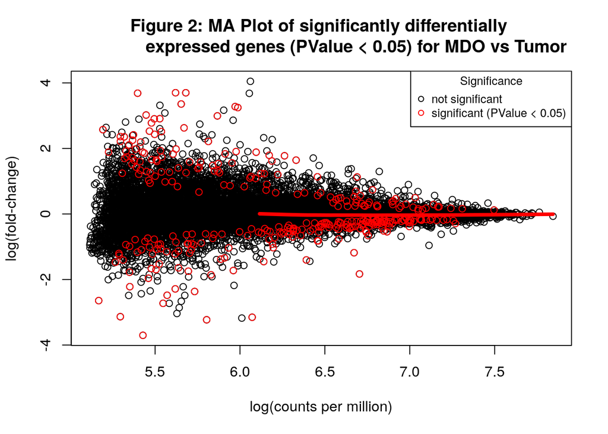

```r
legend("topright", title="Significance",
       legend=c("not significant",
                "significant (PValue < 0.05)"),
       col=c("black", "red"), pch=1, cex=0.8)
```

**Figure 2** visualizes the differential expression analysis results for genes comparing Metastasis-Derived Organoids (MDO) to Tumor samples. In this plot, the log fold change (logFC) is plotted against the log counts per million (logCPM), providing a clear visualization of how gene expression varies between these two cell types. The red points indicate genes that are significantly differentially expressed with a p-value less than 0.05, highlighting those genes that stand out based on their expression changes, despite none passing the FDR correction for multiple testing. The inclusion of a LOWESS line (locally weighted scatterplot smoothing) helps to identify overall trends in the data, emphasizing systematic shifts in gene expression or potential biases.

```r
# For PDO vs. Tumor Comparison
edgeR::maPlot(logAbundance=qlf_PDO_hits$table$logCPM,
              logFC=qlf_PDO_hits$table$logFC,
              de.tags=which(qlf_PDO_hits$table$PValue < 0.05),
              lowess=TRUE,
              xlab="log(counts per million)",
              ylab="log(fold-change)",
              main="Figure 3: MA Plot of significantly differentially
              expressed genes (PValue < 0.05) for PDO vs Tumor")
```

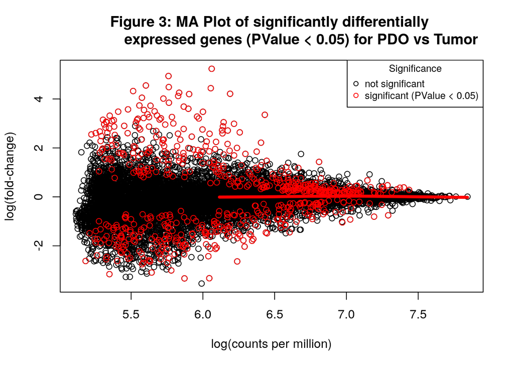

```r
legend("topright", title="Significance",
       legend=c("not significant",
                "significant (PValue < 0.05)"),
       col=c("black", "red"), pch=1, cex=0.8)
```

Similarly, the MA plot in **Figure 3** for the comparison between Patient-Derived Organoids (PDO) and Tumor samples illustrates the log fold changes versus logCPM. Here again, genes with p-values less than 0.05 are marked in red, indicating significant differential expression before correction for multiple comparisons.

#### 3.2 Show the amount of differentially expressed genes using an Volcano Plot

```r
# Basic volcano plot setup
plot(qlf_MDO_hits$table$logFC, -log10(qlf_MDO_hits$table$PValue),
     main="Figure 4: Volcano Plot of Significantly Differentially
     Expressed Genes MDO vs Tumor",
     xlab="Log(fold change)",
     ylab="-log10(p-value)",
     pch=20, col="grey")  # Start with all points in grey
```

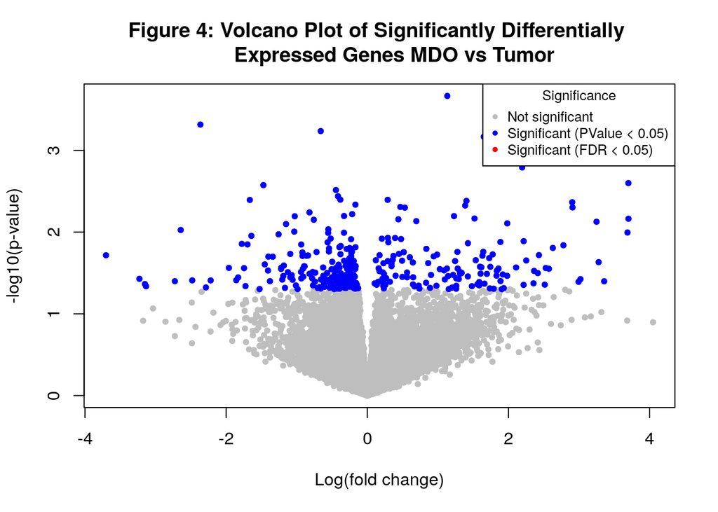

```r
# Highlighting significantly differentially expressed genes by p-value
points(qlf_MDO_hits$table$logFC[which(qlf_MDO_hits$table$PValue < 0.05)],
       -log10(qlf_MDO_hits$table$PValue)[which(qlf_MDO_hits$table$PValue < 0.05)],
       col="blue", pch=20)

# Highlighting significantly differentially expressed genes by FDR
points(qlf_MDO_hits$table$logFC[which(qlf_MDO_hits$table$FDR < 0.05)],
       -log10(qlf_MDO_hits$table$PValue)[which(qlf_MDO_hits$table$FDR < 0.05)],
       col="red", pch=20)

# Adding a legend to the plot
legend("topright", title="Significance",
       legend=c("Not significant",
                "Significant (PValue < 0.05)",
                "Significant (FDR < 0.05)"),
       col=c("grey", "blue", "red"), pch=20, cex=0.8)
```

```r
plot(qlf_PDO_hits$table$logFC, -log10(qlf_PDO_hits$table$PValue),
     main="Figure 5: Volcano Plot of Significantly Differentially
     Expressed Genes PDO vs Tumor",
     xlab="Log(fold change)",
     ylab="-log10(p-value)",
     pch=20, col="grey")  # Start with all points in grey
```

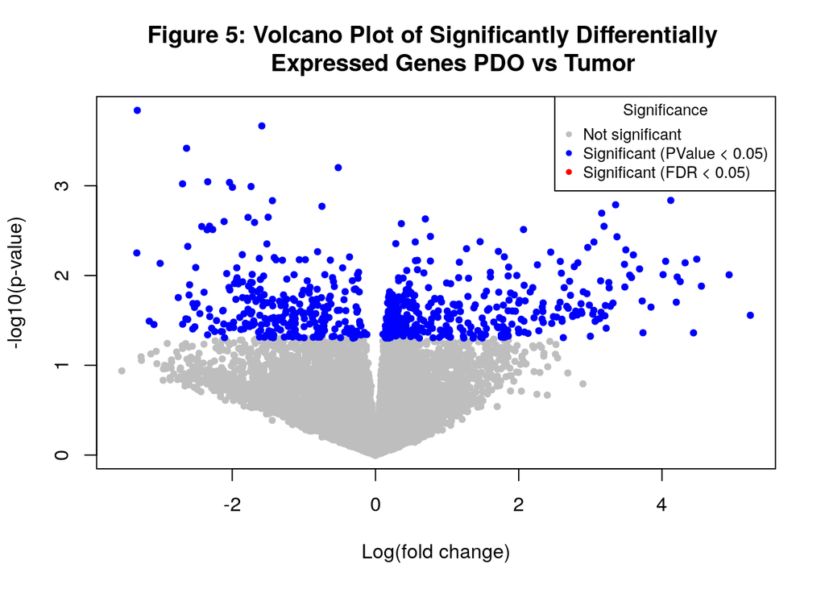

```r
# Highlighting significantly differentially expressed genes by p-value
points(qlf_PDO_hits$table$logFC[which(qlf_PDO_hits$table$PValue < 0.05)],
       -log10(qlf_PDO_hits$table$PValue)[which(qlf_PDO_hits$table$PValue < 0.05)],
       col="blue", pch=20)

# Highlighting significantly differentially expressed genes by FDR
points(qlf_PDO_hits$table$logFC[which(qlf_PDO_hits$table$FDR < 0.05)],
       -log10(qlf_PDO_hits$table$PValue)[which(qlf_PDO_hits$table$FDR < 0.05)],
       col="red", pch=20)

# Adding a legend to the plot
legend("topright", title="Significance",
       legend=c("Not significant",
                "Significant (PValue < 0.05)",
                "Significant (FDR < 0.05)"),
       col=c("grey", "blue", "red"), pch=20, cex=0.8)
```

#### 4.1 Visualize your top hits using a heatmap.

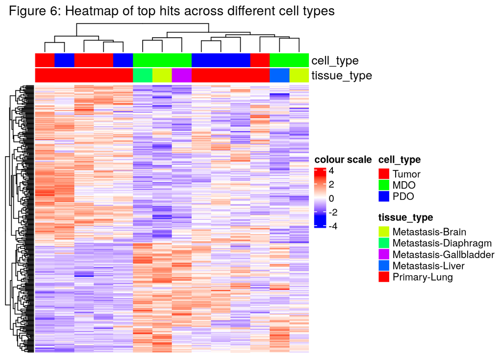

```r
tops <- rownames(qlf.Tumor_vs_MDO$table)[
  qlf.Tumor_vs_MDO$table$PValue < 0.05]

top_genes_MDO_matrix = t(scale(
  t(luad_matrix[which(rownames(luad_matrix) %in% tops),]) ))


if(min(top_genes_MDO_matrix) == 0){
heatmap_col = colorRamp2(c( 0, max(top_genes_MDO_matrix)),
c( "white", "red"))
} else {
heatmap_col = colorRamp2(c(min(top_genes_MDO_matrix), 0,
max(top_genes_MDO_matrix)),
c("blue", "white", "red"))
}


# annotations


unique_celltype <- unique(sample_type_df$`Cell Type`)
unique_celltypecolors <- rainbow(n = length(unique_celltype))
names(unique_celltypecolors) <- unique_celltype


unique_tissuetype <- unique(sample_type_df$`Tissue Type`)
unique_tissuecolors <- rainbow(n = length(unique_tissuetype))
names(unique_tissuecolors) <- unique_tissuetype


ha_pat <- HeatmapAnnotation(df = data.frame(cell_type = sample_type_df$`Cell Type`,
                                            tissue_type = sample_type_df$`Tissue Type`),
                                            col = list(cell_type = unique_celltypecolors,
                                                       tissue_type = unique_tissuecolors),
                                            show_legend = TRUE)

current_heatmap <- Heatmap(as.matrix(top_genes_MDO_matrix),
                          top_annotation = ha_pat,
                          cluster_rows = TRUE,
                          cluster_columns = TRUE,
                          show_row_dend = TRUE,
                          show_column_dend = TRUE,
                          col=heatmap_col,
                          show_column_names = FALSE,
                          show_row_names = FALSE,
                          show_heatmap_legend = TRUE,
                          name="colour scale",
                          column_title = ("Figure 6: Heatmap of top hits across different cell types"))
current_heatmap
```

## Thresholded over-representation analysis

Task: With your significantly up-regulated and down-regulated set of genes run a thresholded gene set enrichment analysis

```r
# create non-thresholded gene sets
MDO_nt_geneset <- qlf_MDO_hits$table
MDO_nt_geneset[,"rank"] <- -log10(MDO_nt_geneset$PValue) * sign(MDO_nt_geneset$logFC)
MDO_nt_geneset <- MDO_nt_geneset[order(MDO_nt_geneset$rank),]

PDO_nt_geneset <- qlf_PDO_hits$table
PDO_nt_geneset[,"rank"] <- -log10(PDO_nt_geneset$PValue) * sign(PDO_nt_geneset$logFC)
PDO_nt_geneset <- PDO_nt_geneset[order(PDO_nt_geneset$rank),]
```

#### 1.1 Which method did you choose and why?

g:Profiler will be used to run over-representation analysis as that is the method taught in class, and I had practiced this tool using instructions from the online tutorial.

#### 2.1 What annotation data did you use and why?

For the over-representation analysis (ORA) of gene sets, the annotation data sources chosen were “GO:BP” (Gene Ontology: Biological Process), “KEGG” (Kyoto Encyclopedia of Genes and Genomes), “REAC” (Reactome Pathways), and “WP” (WikiPathways).

WP, GO:BP, and REAC were suggested in the tutorial. Using GO:BP helps identify specific biological processes that are enriched in the gene set, providing insights into the biological mechanisms potentially altered in the study’s conditions. Reactome offers an in-depth look at various biological pathways, including more comprehensive coverage of pathway reactions and interactions than some other resources. WikiPathways allows for the integration of the most current and frequently updated pathway information, contributed by a global community of researchers.

KEGG was added due to its excellence for understanding the complex interactions of pathways and how various genes contribute to specific metabolic and signaling pathways.

#### 2.2 What version of the annotation are you using?

The `g:Profiler` version used:

- `g:Profiler` version: **e112_eg59_p19_25aa4782**
- `biomaRt` version: **112**

The annotation sources used in query:

- `GO:BP` version **annotations: BioMart classes: releases/2024-10-27**
- `REAC` version **annotations: BioMart classes: 2025-2-3**
- `WP` version **20250110**
- `KEGG` version **KEGG FTP Release 2024-01-22**

#### 3.1 How many genesets were returned with what thresholds?

#### 4.1 Run the analysis using the up-regulated set of genes, and the down-regulated set of genes separately. How do these results compare to using the whole list (i.e all differentially expressed genes together vs. the up-regulated and down regulated differentially expressed genes separately)?

Question 3 and 4 will be performed together for better presentation and easier interpretation.

For the MDO group:

```r
up_genes_MDO <- rownames(MDO_nt_geneset)[which(MDO_nt_geneset$PValue < 0.05
                                    & MDO_nt_geneset$logFC > 0)]
down_genes_MDO <- rownames(MDO_nt_geneset)[which(MDO_nt_geneset$PValue < 0.05
                                      & MDO_nt_geneset$logFC < 0)]

all_genes_MDO <- rownames(MDO_nt_geneset)[which(MDO_nt_geneset$PValue < 0.05)]
```

```r
# Run ORA for up-regulated genes
gost_up <- gprofiler2::gost(
  query = up_genes_MDO,
  organism = "hsapiens",
  correction_method = "fdr",
  exclude_iea = TRUE,
  ordered_query = FALSE,
  significant = FALSE,
  sources = c("GO:BP", "KEGG", "REAC", "WP")
)

# Run ORA for down-regulated genes
gost_down <- gprofiler2::gost(
  query = down_genes_MDO,
  organism = "hsapiens",
  correction_method = "fdr",
  exclude_iea = TRUE,
  ordered_query = FALSE,
  significant = FALSE,
  sources = c("GO:BP", "KEGG", "REAC", "WP")
)

# Run ORA for all genes
gost_all <- gprofiler2::gost(
  query = all_genes_MDO,
  organism = "hsapiens",
  correction_method = "fdr",
  exclude_iea = TRUE,
  ordered_query = FALSE,
  significant = FALSE,
  sources = c("GO:BP", "KEGG", "REAC", "WP")
)
```

Table 1: Summary of Gene Set Enrichment Analysis Results for MDO

| Category | Number of Gene Sets |
| --- | --- |
| Upregulated Genes | 2855 |
| Downregulated Genes | 3058 |
| All Genes | 4507 |

```r
# Filter gene sets with a minimum of 5 genes and a maximum of 500 genes
gost_up_filtered <- gost_up$result[gost_up$result$term_size >= 5 & gost_up$result$term_size <= 500, ]
gost_down_filtered<- gost_down$result[gost_down$result$term_size >= 5 & gost_down$result$term_size <= 500, ]
gost_all_filtered <- gost_all$result[gost_all$result$term_size >= 5 & gost_all$result$term_size <= 500, ]
```

Table 2: Summary of Gene Set Enrichment Analysis Results for MDO After Filtering

| Category | Number of Gene Sets |
| --- | --- |
| Upregulated Genes | 2406 |
| Downregulated Genes | 2573 |
| All Genes | 3937 |

To Visualize Top Regulated Genes:

```r
knitr::kable(gost_up_filtered[1:10, c("term_size", "term_name")],
      row.names = FALSE,
      caption = "**Table 3: Top significant gene sets for upregulated genes for the MDO Group**")
```

**Table 3: Top significant gene sets for upregulated genes for the MDO Group**

| term_size | term_name |
| --- | --- |
| 20 | regulation of CD8-positive, alpha-beta T cell activation |
| 24 | CD8-positive, alpha-beta T cell activation |
| 7 | positive regulation of tolerance induction |
| 30 | alpha-beta T cell proliferation |
| 29 | regulation of alpha-beta T cell proliferation |
| 8 | amyloid-beta clearance by cellular catabolic process |
| 9 | regulation of CD8-positive, alpha-beta T cell proliferation |
| 9 | CD8-positive, alpha-beta T cell proliferation |
| 12 | regulation of tolerance induction |
| 19 | lipid import into cell |

```r
knitr::kable(gost_down_filtered[1:10, c("term_size", "term_name")],
      row.names = FALSE,
      caption = "**Table 4: Top significant gene sets for downregulated genes for the MDO Group**")
```

**Table 4: Top significant gene sets for downregulated genes for the MDO Group**

| term_size | term_name |
| --- | --- |
| 207 | regulation of DNA repair |
| 124 | regulation of MAP kinase activity |
| 437 | regulation of cellular response to stress |
| 141 | regulation of G1/S transition of mitotic cell cycle |
| 6 | ERBB2-EGFR signaling pathway |
| 8 | terpenoid catabolic process |
| 427 | regulation of mitotic cell cycle |
| 166 | regulation of cell cycle G1/S phase transition |
| 435 | regulation of DNA metabolic process |
| 10 | isoprenoid catabolic process |

```r
knitr::kable(gost_all_filtered[1:10, c("term_size", "term_name")],
      row.names = FALSE,
      caption = "**Table 5: Top significant gene sets for all genes for the MDO Group**")
```

**Table 5: Top significant gene sets for all genes for the MDO Group**

| term_size | term_name |
| --- | --- |
| 6 | ERBB2-EGFR signaling pathway |
| 207 | regulation of DNA repair |
| 12 | replicative senescence |
| 14 | ERBB2 signaling pathway |
| 16 | protein trimerization |
| 16 | protein homotrimerization |
| 124 | regulation of MAP kinase activity |
| 20 | regulation of CD8-positive, alpha-beta T cell activation |
| 102 | positive regulation of proteasomal protein catabolic process |
| 21 | positive regulation of muscle contraction |

For the PDO group:

```r
up_genes_PDO <- rownames(PDO_nt_geneset)[which(PDO_nt_geneset$PValue < 0.05
                                    & PDO_nt_geneset$logFC > 0)]
down_genes_PDO <- rownames(PDO_nt_geneset)[which(PDO_nt_geneset$PValue < 0.05
                                      & PDO_nt_geneset$logFC < 0)]

all_genes_PDO <- rownames(PDO_nt_geneset)[which(PDO_nt_geneset$PValue < 0.05)]
```

```r
# Run ORA for up-regulated genes
gost_up <- gprofiler2::gost(
  query = up_genes_PDO,
  organism = "hsapiens",
  correction_method = "fdr",
  exclude_iea = TRUE,
  ordered_query = FALSE,
  significant = FALSE,
  sources = c("GO:BP", "KEGG", "REAC", "WP")
)

# Run ORA for down-regulated genes
gost_down <- gprofiler2::gost(
  query = down_genes_PDO,
  organism = "hsapiens",
  correction_method = "fdr",
  exclude_iea = TRUE,
  ordered_query = FALSE,
  significant = FALSE,
  sources = c("GO:BP", "KEGG", "REAC", "WP")
)

# Run ORA for all genes
gost_all <- gprofiler2::gost(
  query = all_genes_PDO,
  organism = "hsapiens",
  correction_method = "fdr",
  exclude_iea = TRUE,
  ordered_query = FALSE,
  significant = FALSE,
  sources = c("GO:BP", "KEGG", "REAC", "WP")
)
```

Table 6: Summary of Gene Set Enrichment Analysis Results for PDO

| Category | Number of Gene Sets |
| --- | --- |
| Upregulated Genes | 4533 |
| Downregulated Genes | 3966 |
| All Genes | 6266 |

```r
# Filter gene sets with a minimum of 5 genes and a maximum of 500 genes
gost_up_filtered <- gost_up$result[gost_up$result$term_size >= 5 & gost_up$result$term_size <= 500, ]
gost_down_filtered<- gost_down$result[gost_down$result$term_size >= 5 & gost_down$result$term_size <= 500, ]
gost_all_filtered <- gost_all$result[gost_all$result$term_size >= 5 & gost_all$result$term_size <= 500, ]
```

Table 7: Summary of Gene Set Enrichment Analysis Results for PDO After Filtering

| Category | Number of Gene Sets |
| --- | --- |
| Upregulated Genes | 3943 |
| Downregulated Genes | 3422 |
| All Genes | 5498 |

To Visualize Top Regulated Genes:

```r
knitr::kable(gost_up_filtered[1:10, c("term_size", "term_name")],
      row.names = FALSE,
      caption = "**Table 8: Top significant gene sets for upregulated genes for the PDO Group**")
```

**Table 8: Top significant gene sets for upregulated genes for the PDO Group**

| term_size | term_name |
| --- | --- |
| 231 | epidermis development |
| 168 | skin development |
| 142 | epidermal cell differentiation |
| 102 | keratinocyte differentiation |
| 454 | epithelial cell differentiation |
| 85 | intermediate filament cytoskeleton organization |
| 86 | intermediate filament-based process |
| 71 | intermediate filament organization |
| 21 | establishment of skin barrier |
| 33 | keratinization |

```r
knitr::kable(gost_down_filtered[1:10, c("term_size", "term_name")],
      row.names = FALSE,
      caption = "**Table 9: Top significant gene sets for downregulated genes for the PDO Group**")
```

**Table 9: Top significant gene sets for downregulated genes for the PDO Group**

| term_size | term_name |
| --- | --- |
| 39 | smooth muscle cell differentiation |
| 44 | negative regulation of BMP signaling pathway |
| 23 | vascular associated smooth muscle cell differentiation |
| 166 | calcium-mediated signaling |
| 78 | regulation of BMP signaling pathway |
| 126 | negative regulation of transmembrane receptor protein serine/threonine kinase signaling pathway |
| 26 | regulation of smooth muscle cell differentiation |
| 117 | BMP signaling pathway |
| 84 | negative regulation of cellular response to growth factor stimulus |
| 434 | leukocyte differentiation |

```r
knitr::kable(gost_all_filtered[1:10, c("term_size", "term_name")],
      row.names = FALSE,
      caption = "**Table 10: Top significant gene sets for all genes for the PDO Group**")
```

**Table 10: Top significant gene sets for all genes for the PDO Group**

| term_size | term_name |
| --- | --- |
| 231 | epidermis development |
| 168 | skin development |
| 142 | epidermal cell differentiation |
| 102 | keratinocyte differentiation |
| 454 | epithelial cell differentiation |
| 71 | intermediate filament organization |
| 85 | intermediate filament cytoskeleton organization |
| 86 | intermediate filament-based process |
| 21 | establishment of skin barrier |
| 33 | keratinization |

### Interpretation

#### 1. Do the over-representation results support conclusions or mechanism discussed in the original paper?

The Original Paper mentioned that they founds overexpressed genes (TFPI2, IL1B, SAA1, and SAA2) and underexpressed genes (BTG2 and FGFBP1) in metastases. Thus, the ORA results do provide support to some extent:

**Upregulated Genes:** The significant enrichment in terms related to “CD8-positive, alpha-beta T cell activation” and various forms of T cell proliferation (e.g., “alpha-beta T cell proliferation”) suggests an active immune response or an immune-related mechanism in the MDO context. The mention of genes like TFPI2 and IL1B, which are known for their roles in inflammation and immune responses, correlates well with these enriched immune-related pathways. TFPI2 is known for its anti-inflammatory properties, while IL1B is a critical cytokine in the immune response.

The presence of pathways such as “amyloid-beta clearance” might indicate additional cellular functions that are upregulated in metastases, possibly related to cellular stress responses or other neuroinflammatory processes.

**Downregulated Genes:** The downregulation of pathways like “regulation of DNA repair” and “regulation of MAP kinase activity” might reflect changes in cell cycle control and DNA damage response, supporting the downregulation of genes like BTG2 which is known for its role in cell cycle regulation and tumor suppression. The “regulation of cellular response to stress” and “regulation of cell cycle G1/S phase transition” being affected aligns with the downregulation of FGFBP1, a gene implicated in cell proliferation and extracellular matrix interaction during cancer progression.

#### 2. Can you find evidence, i.e. publications, to support some of the results that you see. How does this evidence support your results.

Studies have shown that CD8+ T cells play a crucial role in the immune surveillance of tumors and can be activated in response to tumor antigens(Gatti-Mays & Gulley, 2021). The enrichment of T cell activation pathways suggests a possible immune evasion mechanism or a heightened immune response in the metastatic niche that could be related to the overexpression of inflammatory genes like IL1B.

Research indicates that disruptions in DNA repair mechanisms are a hallmark of many cancers, leading to genomic instability and tumor progression (Hamidi & Ivaska, 2018). The downregulation of these pathways in MDOs might reflect a compromised DNA repair capacity typical of more aggressive or advanced-stage cancers, supporting the observed downregulation of BTG2.

The MAP kinase pathway is integral to cell growth and differentiation signals. Its dysregulation is linked to various cancers (Source: Cancer Discovery, 2015, 5(7), 730–743. DOI: 10.1158/2159-8290.CD-14-0736). The downregulation of this pathway could indicate a disruption in these signaling processes, consistent with the cancer progression and metastatic behavior noted in the study.

## Link to Journal

[Assignment 2](https://github.com/bcb420-2025/Keren_Zhang/wiki/Assignment-2)

## References

The R packages used in the analysis include: `GEOquery` (Davis & Meltzer, 2007), `edgeR` (Chen, Chen, Lun, Baldoni, & Smyth, 2025), `biomaRt` (Durinck, Spellman, Birney, & Huber, 2009), `ggplot2` (Wickham, 2016), `dplyr` (Wickham, François, Henry, Müller, & Vaughan, 2023), `tidyr` (Wickham, Vaughan, & Girlich, 2024), `limma` (Ritchie et al., 2015), `circlize` (Gu, Gu, Eils, Schlesner, & Brors, 2014), `gprofiler2` (Kolberg, Raudvere, Kuzmin, Vilo, & Peterson, 2020), and `knitr` (Xie, 2024).

Chen, Y., Chen, L., Lun, A. T. L., Baldoni, P. L., & Smyth, G. K. (2025). edgeR v4: Powerful differential analysis of sequencing data with expanded functionality and improved support for small counts and larger datasets. *Nucleic Acids Research*, *53*(2), gkaf018. https://doi.org/10.1093/nar/gkaf018

Davis, S., & Meltzer, P. (2007). GEOquery: A bridge between the gene expression omnibus (GEO) and BioConductor. *Bioinformatics*, *14*, 1846–1847.

Durinck, S., Spellman, P., Birney, E., & Huber, W. (2009). Mapping identifiers for the integration of genomic datasets with the r/bioconductor package biomaRt. *Nature Protocols*, *4*, 1184–1191. https://doi.org/10.1038/nprot.2009.97

Gatti-Mays, M. E., & Gulley, J. L. (2021). Real-world insights on preferred treatments for steroid-refractory immune checkpoint inhibitor-induced pneumonitis. *Journal for Immunotherapy of Cancer*, *9*(2), e002252. https://doi.org/10.1136/jitc-2020-002252

Gu, Z., Gu, L., Eils, R., Schlesner, M., & Brors, B. (2014). Circlize implements and enhances circular visualization in r. *Bioinformatics*, *30*, 2811–2812.

Hamidi, H., & Ivaska, J. (2018). Every step of the way: Integrins in cancer progression and metastasis. *Nature Reviews. Cancer*, *18*(9), 533–548. https://doi.org/10.1038/s41568-018-0038-z

Kolberg, L., Raudvere, U., Kuzmin, I., Vilo, J., & Peterson, H. (2020). gprofiler2– an r package for gene list functional enrichment analysis and namespace conversion toolset g:profiler. *F1000Research*, *9 (ELIXIR)*(709).

Liu, Y., Lankadasari, M., Rosiene, J., Johnson, K., Zhou, J., Bapat, S., … Jones, D. (2024). Modeling lung adenocarcinoma metastases using patient-derived organoids. *Cell Rep Med*, *5*(10), 101777. https://doi.org/10.1016/j.xcrm.2024.101777

Ritchie, M. E., Phipson, B., Wu, D., Hu, Y., Law, C. W., Shi, W., & Smyth, G. K. (2015). limma powers differential expression analyses for RNA-sequencing and microarray studies. *Nucleic Acids Research*, *43*(7), e47. https://doi.org/10.1093/nar/gkv007

Wickham, H. (2016). *ggplot2: Elegant graphics for data analysis*. Springer-Verlag New York. Retrieved from https://ggplot2.tidyverse.org

Wickham, H., François, R., Henry, L., Müller, K., & Vaughan, D. (2023). *Dplyr: A grammar of data manipulation*. Retrieved from https://CRAN.R-project.org/package=dplyr

Wickham, H., Vaughan, D., & Girlich, M. (2024). *Tidyr: Tidy messy data*. Retrieved from https://CRAN.R-project.org/package=tidyr

Xie, Y. (2024). *Knitr: A general-purpose package for dynamic report generation in r*. Retrieved from https://yihui.org/knitr/

Zappa, C., & Mousa, S. A. (2016). Non-small cell lung cancer: Current treatment and future advances. *Translational Lung Cancer Research*, *5*(3), 288–300. https://doi.org/10.21037/tlcr.2016.06.07